# Project 2

Tran Minh Nhat-2014008

11/10/2021

# `A. HỒI QUY TUYẾN TÍNH BỘI`

**CÂU 2:** Tập tin “diem_so.csv” chứa thông tin về điểm toán của các em học sinh trung học thuộc hai trường học ở Bồ Đào Nha. Các thuộc tính dữ liệu bao gồm điểm học sinh, nơi cư trú, và một số hoạt động xã hội khác. Dữ liệu được thu thập bằng cách sử dụng báo cáo của các trường và các kết quả khảo sát sinh viên. Dữ liệu gốc được cung cấp tại: https://archive.ics.uci.edu/ml/datasets/student+performance.

Các biến chính trong bộ dữ liệu:

- *G1*: Điểm thi học kì 1.
- *G2*: Điểm thi học kì 2.
- *G3*: Điểm cuối khoá.
- *studytime*: Thời gian tự học trên tuần(1 – ít hơn 2 giờ, 2 – từ 2 đến 5 giờ, 3 – từ 5 đến 10 giờ, or 4 – lớn hơn 10 giờ).
- *failures*: Số lần không qua môn (0, 1, 2, nhiều hơn hoặc bằng 3 lần)
- *absences*: Số lần nghỉ học.
- *higher*: Có muốn học cao hơn hay không (yes: có, no: không).
- *age*: Tuổi của học sinh.

**THỰC HIỆN**:

**1) ĐỌC DỮ LIỆU**:

Dùng lệnh **read.csv** để đọc tệp tin **diem_so**:

```r
diem_so <- read.csv("~/Desktop/BTL_HK211/Data/grade.csv")  #Đọc tệp tin và lưu với tên 'diem_so'
head(diem_so, 3) #Xuất 3 dòng đầu tiên của data 'diem_so'
```

```
##   X school sex age address famsize Pstatus Medu Fedu    Mjob    Fjob reason
## 1 1     GP   F  18       U     GT3       A    4    4 at_home teacher course
## 2 2     GP   F  17       U     GT3       T    1    1 at_home   other course
## 3 3     GP   F  15       U     LE3       T    1    1 at_home   other  other
##   guardian traveltime studytime failures schoolsup famsup paid activities
## 1   mother          2         2        0       yes     no   no         no
## 2   father          1         2        0        no    yes   no         no
## 3   mother          1         2        3       yes     no  yes         no
##   nursery higher internet romantic famrel freetime goout Dalc Walc health
## 1     yes    yes       no       no      4        3     4    1    1      3
## 2      no    yes      yes       no      5        3     3    1    1      3
## 3     yes    yes      yes       no      4        3     2    2    3      3
##   absences G1 G2 G3
## 1        6  5  6  6
## 2        4  5 NA  6
## 3       10  7  8 10
```

**2) LÀM SẠCH DỮ LIỆU**:

1. Trích ra dữ liệu con, đặt tên data.frame **new_DF** bao gồm các biến chính:

```r
new_DF = diem_so[,c("G1","G2","G3","studytime","failures","absences","higher","age")]
head(new_DF, 3)  #Xuất 3 dòng đầu tiên của data 'new_DF'
```

```
##   G1 G2 G3 studytime failures absences higher age
## 1  5  6  6         2        0        6    yes  18
## 2  5 NA  6         2        0        4    yes  17
## 3  7  8 10         2        3       10    yes  15
```

2. Kiểm tra các dữ liệu bị khuyết trong tệp tin:

```r
apply(is.na(new_DF), 2, which)  #Xuất vị trí dòng chứa NA
```

```
## $G1
## integer(0)
##
## $G2
## [1]   2   6   9  80 100
##
## $G3
## integer(0)
##
## $studytime
## integer(0)
##
## $failures
## integer(0)
##
## $absences
## integer(0)
##
## $higher
## integer(0)
##
## $age
## integer(0)
```

```r
apply(is.na(new_DF),2,sum)  #Tính số lượng NA ở các biến
```

```
##        G1        G2        G3 studytime  failures  absences    higher       age
##         0         5         0         0         0         0         0         0
```

```r
apply(is.na(new_DF),2,mean)  #Tính tỷ lệ NA ở các biến
```

```
##         G1         G2         G3  studytime   failures   absences     higher
## 0.00000000 0.01265823 0.00000000 0.00000000 0.00000000 0.00000000 0.00000000
##        age
## 0.00000000
```

**Nhận xét**: Dựa trên kết quả, ta thấy biến **G2** có 5 NA, chiếm tỷ lệ < 10% so với bộ dữ liệu, nên ta sẽ xử lý NA bằng cách xóa các quan sát bị khuyết của G2.

```r
new_DF <- na.omit(new_DF)    #Xoá các quan sát mà biến nào chứa NA
apply(is.na(new_DF), 2, which)  #Xuất vị trí dòng chứa NA (kiểm tra lại)
```

```
## integer(0)
```

**3) LÀM RÕ DỮ LIỆU**:

1. Các biến liên tục trong dữ liệu là: **G1, G2, G3, age**

Tính các giá trị thống kê mô tả của các biến liên tục trong dữ liệu:

```r
mean <- apply(new_DF[,c(1,2,3,8)],2,mean)
#Tính trung bình mẫu ở các biến liên tục trong dữ liệu.
sd <- apply(new_DF[,c(1,2,3,8)],2,sd)
#Tính độ lệch mẫu hiệu chỉnh ở các biến liên tục trong dữ liệu.
median <- apply(new_DF[,c(1,2,3,8)],2,median)
#Tính trung vị ở các biến liên tục trong dữ liệu.
max <- apply(new_DF[,c(1,2,3,8)],2,max)
#Tính giá trị lớn nhất ở các biến liên tục trong dữ liệu.
min <- apply(new_DF[,c(1,2,3,8)],2,min)
#Tính giá trị nhỏ nhất ở các biến liên tục trong dữ liệu.
```

Dùng hàm **data.frame** để xuất kết quả dưới dạng bảng thống kê:

```r
Thong_ke <- data.frame(mean,median,sd,max,min)  #Tạo bảng thống kê
Thong_ke  #Xem kết quả
```

```
##         mean median       sd max min
## G1  10.92564     11 3.290886  19   3
## G2  10.71795     11 3.737868  19   0
## G3  10.41282     11 4.568962  20   0
## age 16.70513     17 1.279751  22  15
```

2. Dùng hàm **table** để lập bảng thống kê số lượng cho **failures, studytime, higher**:

```r
table(new_DF$failures)  #Tạo bảng thống kê số lượng cho từng phân loại biến 'failures'
```

```
##
##   0   1   2   3
## 307  50  17  16
```

```r
table(new_DF$studytime)  #Tạo bảng thống kê số lượng cho từng phân loại biến 'studytime'
```

```
##
##   1   2   3   4
## 105 194  64  27
```

```r
table(new_DF$higher)  #Tạo bảng thống kê số lượng cho từng phân loại  biến 'higher'
```

```
##
##  no yes
##  20 370
```

3. Dùng hàm **hist** để vẽ đồ thị phân phối của biến **G3**:

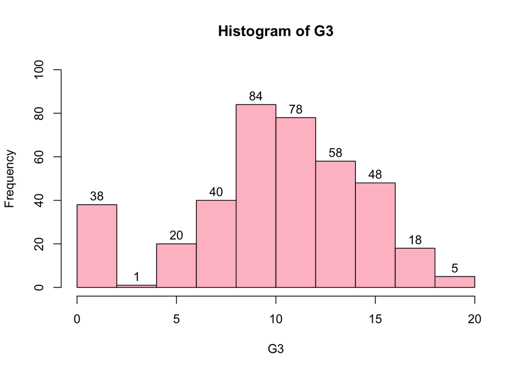

```r
hist(new_DF$G3,xlab = "G3", main = "Histogram of G3", ylim=c(0,100), labels = T,col = "pink")
```

```r
#Vẽ đồ thị phân phối tần số Histogram của biến 'G3'
```

**Nhận xét:** Đây là biểu đồ phân bố tần số cho biến **G3**. Dựa trên biểu đồ ta nhận thấy:

- Mức điểm có số lượng sinh viên nhiều nhất là: 8 - 10 điểm
- Mức điểm có số lương sinh viên ít nhất là: 2 - 4 điểm

Ngoài ra, có 38 sinh viên có điểm tổng kết là từ 0 - 2 điểm. Điều này có thể là nguyên nhân ảnh hưởng đến mô hình hồi quy ta xây dựng.

4. Dùng hàm **boxplot** để vẽ phân phối của biến **G3** lần lượt theo từng phân loại của các biến **failures, studytime, higher**:

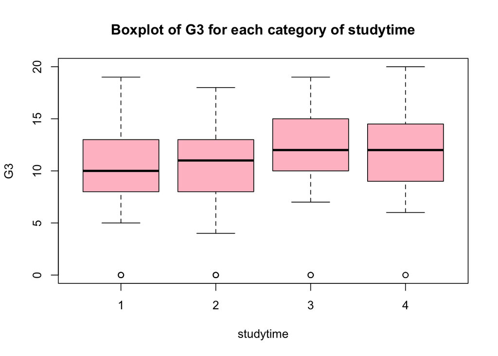

```r
boxplot(G3 ~ studytime, main = "Boxplot of G3 for each category of studytime", data = new_DF,col = "pink")
```

```r
#Vẽ biểu đồ hộp của biến 'G3' theo phân loại biến 'studytime'
```

**Nhận xét:**

Đối với nhóm sinh viên có thời gian tự học trong tuần thuộc nhóm 1 (ít hơn 2 giờ):

- Điểm cuối khoá cao nhất khoảng 19 điểm.
- Điểm cuối khoá thấp nhất là 0 điểm.
- Có 25% học sinh có điểm cuối khoá khoảng dưới 8 điểm.
- Có 50% học sinh có điểm cuối khoá khoảng dưới 10 điểm.
- Có 75% học sinh có điểm cuối khoá khoảng dưới 13 điểm.

Đối với nhóm sinh viên có thời gian tự học trong tuần thuộc nhóm 3 (từ 5 đến 10 giờ):

- Điểm cuối khoá cao nhất khoảng 19 điểm.
- Điểm cuối khoá thấp nhất là 0 điểm.
- Có 25% học sinh có điểm cuối khoá khoảng dưới 10 điểm.
- Có 50% học sinh có điểm cuối khoá khoảng dưới 12 điểm.
- Có 75% học sinh có điểm cuối khoá khoảng dưới 15 điểm.

Đối với nhóm sinh viên có thời gian tự học trong tuần thuộc nhóm 4 (lớn hơn 10 giờ):

- Điểm cuối khoá cao nhất khoảng 20 điểm.
- Điểm cuối khoá thấp nhất là 0 điểm.
- Có 25% học sinh có điểm cuối khoá khoảng dưới 9 điểm.
- Có 50% học sinh có điểm cuối khoá khoảng dưới 12 điểm.
- Có 75% học sinh có điểm cuối khoá khoảng dưới 15 điểm.

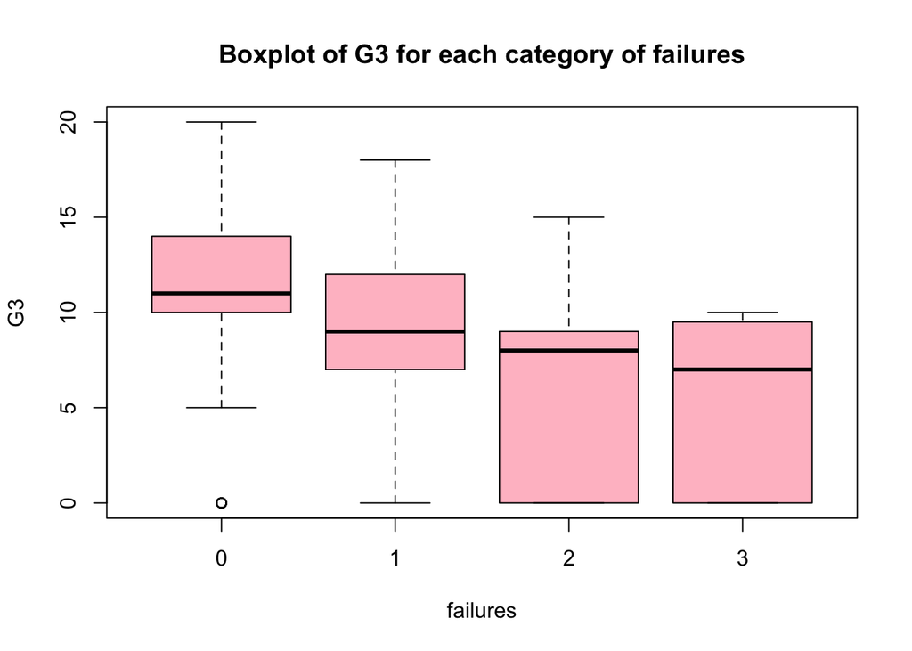

```r
boxplot(G3 ~ failures, main ="Boxplot of G3 for each category of failures", data = new_DF, col = "pink")
```

```r
#Vẽ biểu đồ hộp của biến 'G3' theo phân loại biến 'failures'
```

**Nhận xét:**

Đối với nhóm sinh viên có số lần không qua môn thuộc nhóm 3 (2 lần):

- Điểm cuối khoá cao nhất khoảng 15 điểm.
- Điểm cuối khoá thấp nhất là 0 điểm.
- Có 50% học sinh có điểm cuối khoá khoảng dưới 8 điểm.
- Có 75% học sinh có điểm cuối khoá khoảng dưới 9 điểm.

Đối với nhóm sinh viên có số lần không qua môn thuộc nhóm 4 ($\geq 3$ lần):

- Điểm cuối khoá cao nhất khoảng 10 điểm.
- Điểm cuối khoá thấp nhất là 0 điểm.
- Có 50% học sinh có điểm cuối khoá khoảng dưới 7 điểm.
- Có 75% học sinh có điểm cuối khoá khoảng dưới 9 điểm.

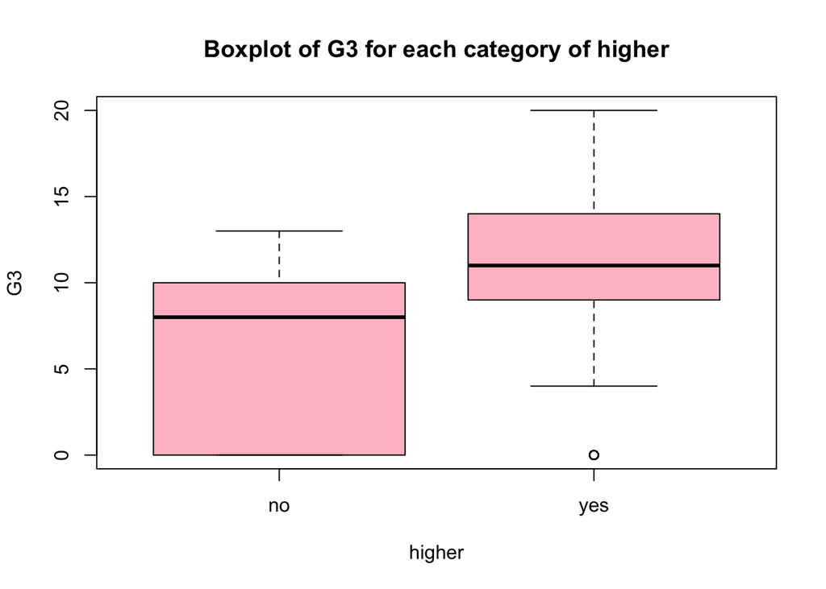

```r
boxplot(G3 ~ higher, main ="Boxplot of G3 for each category of higher", data = new_DF, col = "pink")
```

```r
#Vẽ biểu đồ hộp của biến 'G3' theo phân loại biến 'higher'
```

**Nhận xét:**

Đối với nhóm sinh viên không muốn học cao hơn:

- Điểm cuối khoá cao nhất khoảng 13 điểm.
- Điểm cuối khoá thấp nhất là 0 điểm.
- Có 50% học sinh có điểm cuối khoá khoảng dưới 8 điểm.
- Có 75% học sinh có điểm cuối khoá khoảng dưới 10 điểm.

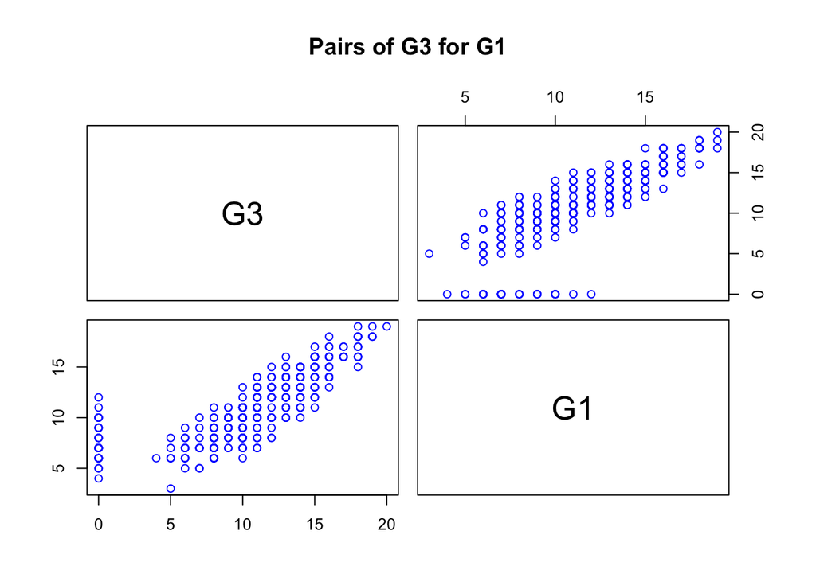

```r
pairs(G3 ~ G1, main ="Pairs of G3 for G1", col ="blue", data = new_DF)
```

```r
#Vẽ biểu đồ phân tán của biến 'G3' lần lượt theo biến 'G1'
```

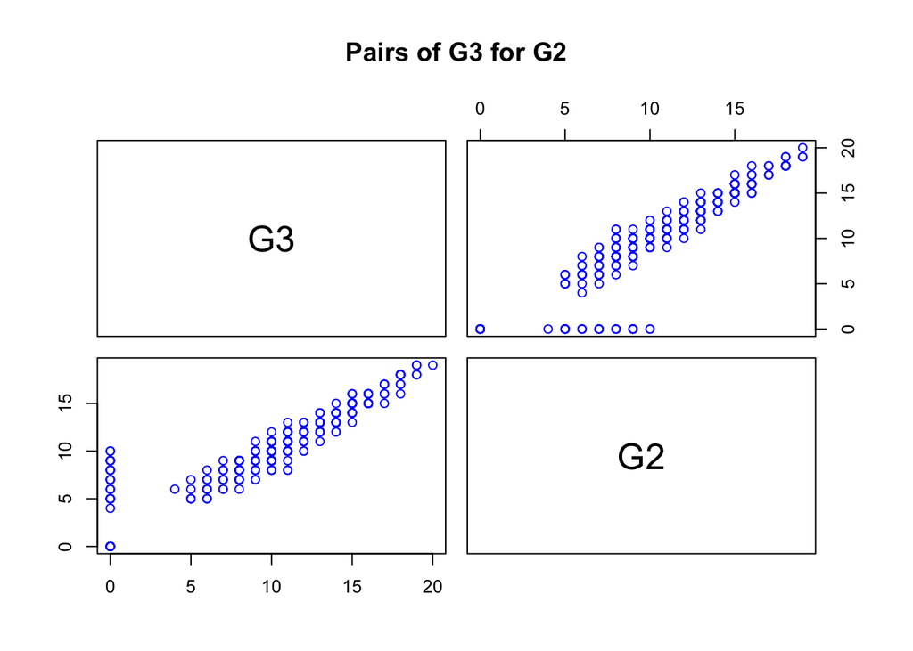

```r
pairs(G3 ~ G2, main ="Pairs of G3 for G2", col ="blue", data = new_DF)
```

```r
#Vẽ biểu đồ phân tán của biến 'G3' lần lượt theo biến 'G2'
```

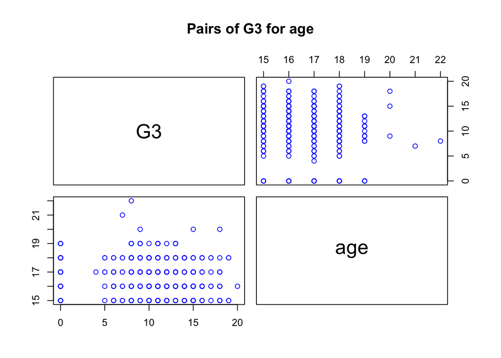

```r
pairs(G3 ~ age, main ="Pairs of G3 for age", col ="blue", data = new_DF)
```

```r
#Vẽ biểu đồ phân tán của biến 'G3' lần lượt theo biến 'age'
```

**Nhận xét**: Từ các đồ thị phân tán, ta có thể nhận xét rằng các biến **G1** và **G2** có mối quan hệ tuyến tính với biến **G3** (nói rõ hơn là quan hệ đồng biến) trong khi biến **age** không có mối quan hệ với biến **G3**.

**4) XÂY DỰNG MÔ HÌNH HỒI QUY TUYẾN TÍNH**:

Chúng ta muốn khám phá rằng có những nhân tố nào và tác động như thế nào đến điểm cuối khoá môn Toán của các em học sinh. a) Ta sẽ xây dựng các mô hình hồi quy bội bao gồm:

Biến phụ thuộc: **G3**.

Biến dư báo (biến độc lập): **G1, G2, failures, studytime, higher, absences, age**.

Ta sử dụng lệnh **lm** để xây dựng mô hình hồi quy tuyến tính bội:

```r
M1 = lm(G3 ~ G1 + G2 + studytime + failures + absences + higher + age, data = new_DF)  #Xây dựng mô hình M1
summary(M1)  #Tóm tắt mô hình 1
```

```
##
## Call:
## lm(formula = G3 ~ G1 + G2 + studytime + failures + absences +
##     higher + age, data = new_DF)
##
## Residuals:
##     Min      1Q  Median      3Q     Max
## -9.0173 -0.4406  0.2876  0.9993  3.5632
##
## Coefficients:
##             Estimate Std. Error t value Pr(>|t|)
## (Intercept)  0.82973    1.49802   0.554 0.579980
## G1           0.16973    0.05684   2.986 0.003009 **
## G2           0.96167    0.04991  19.266  < 2e-16 ***
## studytime   -0.17550    0.11874  -1.478 0.140222
## failures    -0.19569    0.14779  -1.324 0.186254
## absences     0.04104    0.01228   3.343 0.000912 ***
## higheryes    0.20534    0.47078   0.436 0.662964
## age         -0.15473    0.08103  -1.910 0.056929 .
## ---
## Signif. codes:  0 '***' 0.001 '**' 0.01 '*' 0.05 '.' 0.1 ' ' 1
##
## Residual standard error: 1.911 on 382 degrees of freedom
## Multiple R-squared:  0.8281, Adjusted R-squared:  0.825
## F-statistic: 262.9 on 7 and 382 DF,  p-value: < 2.2e-16
```

2. Dựa vào kết quả của mô hình hồi quy tuyến tính trên, ta đặt giả thiết:

Giả thiết $\rm{H}$: Các hệ số hồi quy ứng với các biến không có ý nghĩa thống kê

Giả thiết $\overline{\rm H}$: Các hệ số hồi quy ứng với các biến có ý nghĩa thống kê

Vì Pr ứng với các biến studytime, failure, higher, age đều lớn hơn mức ý nhĩa $\alpha = 0,05$ và $\alpha = 0,01$ nên ta chấp nhận giả thuyết $\rm H$. Do đó các hệ số ứng với các biến trên không có ý nghĩa thống kê, ta sẽ loại bỏ các biến này ra khỏi mô hình.

Các hệ số ứng với các biến còn lại đều có Pr bé hơn mức ý nghĩa $\alpha = 0,05$ và $\alpha = 0,01$, nên ta sẽ bác bỏ $\rm{H}$, chấp nhận $\overline{\rm H}$, tức hệ số hồi quy ứng với các biến này có ý nghĩa thống kê. Do đó, ta không cần loại bỏ những biến này ra khỏi mô hình.

3. Xét 3 mô hình tuyến tính cùng bao gồm biến **G3** là biến phụ thuộc nhưng:

• Mô hình 1 chứa tất cả các biến còn lại là biến độc lập.

• Mô hình 2 là loại bỏ biến **higher** từ mô hình 1.

• Mô hình 3 là loại bỏ biến **failure** từ mô hình 2.

Ta xây dựng mô hình 2:

```r
M2 = lm(G3 ~ G1 + G2 + studytime + failures + absences + age, data = new_DF)  #Xây dựng mô hình M2
summary(M2)  #Tóm tắt mô hình 2
```

```
##
## Call:
## lm(formula = G3 ~ G1 + G2 + studytime + failures + absences +
##     age, data = new_DF)
##
## Residuals:
##     Min      1Q  Median      3Q     Max
## -8.9903 -0.4391  0.2825  0.9981  3.6116
##
## Coefficients:
##             Estimate Std. Error t value Pr(>|t|)
## (Intercept)  1.09287    1.36972   0.798  0.42544
## G1           0.17064    0.05674   3.007  0.00281 **
## G2           0.96179    0.04986  19.289  < 2e-16 ***
## studytime   -0.16879    0.11761  -1.435  0.15206
## failures    -0.20866    0.14461  -1.443  0.14987
## absences     0.04101    0.01227   3.343  0.00091 ***
## age         -0.16003    0.08002  -2.000  0.04622 *
## ---
## Signif. codes:  0 '***' 0.001 '**' 0.01 '*' 0.05 '.' 0.1 ' ' 1
##
## Residual standard error: 1.909 on 383 degrees of freedom
## Multiple R-squared:  0.828,  Adjusted R-squared:  0.8254
## F-statistic: 307.4 on 6 and 383 DF,  p-value: < 2.2e-16
```

Ta xây dựng mô hình 3:

```r
M3 = lm(G3 ~ G1 + G2 + studytime + absences + age, data = new_DF)  #Xây dựng mô hình M3
summary(M3)  #Tóm tắt mô hình 3
```

```
##
## Call:
## lm(formula = G3 ~ G1 + G2 + studytime + absences + age, data = new_DF)
##
## Residuals:
##     Min      1Q  Median      3Q     Max
## -9.0823 -0.4465  0.2949  1.0233  3.5108
##
## Coefficients:
##             Estimate Std. Error t value Pr(>|t|)
## (Intercept)  1.23142    1.36827   0.900 0.368694
## G1           0.18119    0.05635   3.215 0.001413 **
## G2           0.96708    0.04980  19.421  < 2e-16 ***
## studytime   -0.14715    0.11682  -1.260 0.208561
## absences     0.04082    0.01228   3.323 0.000975 ***
## age         -0.18542    0.07817  -2.372 0.018192 *
## ---
## Signif. codes:  0 '***' 0.001 '**' 0.01 '*' 0.05 '.' 0.1 ' ' 1
##
## Residual standard error: 1.912 on 384 degrees of freedom
## Multiple R-squared:  0.8271, Adjusted R-squared:  0.8249
## F-statistic: 367.4 on 5 and 384 DF,  p-value: < 2.2e-16
```

Sử dụng lệnh **anova** để so sánh mô hình 1 và 2:

```r
anova(M1, M2)  #So sánh mô hình M1 và M2
```

```
## Analysis of Variance Table
##
## Model 1: G3 ~ G1 + G2 + studytime + failures + absences + higher + age
## Model 2: G3 ~ G1 + G2 + studytime + failures + absences + age
##   Res.Df    RSS Df Sum of Sq      F Pr(>F)
## 1    382 1395.7
## 2    383 1396.4 -1  -0.69506 0.1902  0.663
```

**Nhận xét:**

Giả thiết $\rm H$: Hai mô hình 1, 2 hiệu quả như nhau

Giả thiết $\overline{\rm H}$: Hai mô hình 1, 2 hiệu quả khác nhau

Vì xác suất quan sát Pr > mức ý nghĩa $\alpha = 0,05$ nên chấp nhận giả thiết $\rm H$. Vậy mô hình 1, 2 hiệu quả giống nhau.

Sử dụng lệnh **anova** để so sánh mô hình 2 và 3:

```r
anova(M2, M3)  #So sánh mô hình M2 và M3
```

```
## Analysis of Variance Table
##
## Model 1: G3 ~ G1 + G2 + studytime + failures + absences + age
## Model 2: G3 ~ G1 + G2 + studytime + absences + age
##   Res.Df    RSS Df Sum of Sq      F Pr(>F)
## 1    383 1396.4
## 2    384 1404.0 -1   -7.5905 2.0819 0.1499
```

**Nhận xét:**

Giả thiết $\rm H$: Hai mô hình 2, 3 hiệu quả như nhau

Giả thiết $\overline{\rm H}$: Hai mô hình 2, 3 hiệu quả khác nhau

Vì xác suất quan sát Pr > mức ý nghĩa $\alpha = 0,05$ nên chấp nhận giả thiết $\rm H$. Vậy mô hình 2, 3 hiệu quả giống nhau.

3. Để đánh giá sự tác động của các biến lên điểm thi cuối kì, ta quan tâm các hệ số hồi quy p-value tương ứng và các hệ số hồi quy ứng với các biến.

Tương tự cũng như hệ số hồi quy ứng với **G1** = 0,17064 thì ứng với điểm thi **G1** tăng 1đ thì ta có thể kỳ vọng điểm thi cuối kì trung bình tăng 0,17064đ (giả sử rằng các biến dự báo còn lại không đổi).

Tương tự đối với các biến còn lại.

4. Vẽ đồ thị sai số hồi quy và sai số dự báo:

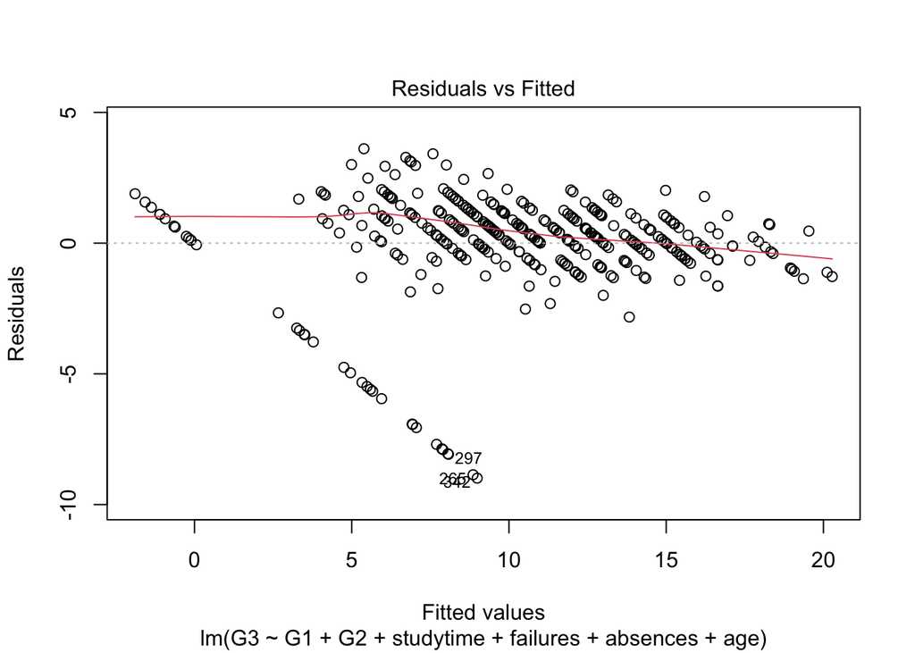

```r
plot(M2, which = 1)  #Vẽ đồ thị sai số hồi quy và sai số dự báo
```

**Nhận xét**: Đường màu đỏ gần như là đường thẳng, có thể nói thỏa mãn giả định tuyến tính giữa **G3** và các biến độc lập. Các sai số hồi quy phân tán đều quanh đường thẳng Y = 0, cho thấy phương sai của các sai số là hằng số. Có nhiều ngoại lai của sai số hồi quy (vì trong mô hình, biến **G3** có nhiều số liệu giá trị 0. Đây là nguyên nhân ảnh hưởng đến mô hình hồi quy chưa thực sự tốt. Ta cần xử lí trước khi xây dựng mô hình để mô hình tốt hơn.

**Các giả định của mô hình hồi quy cần kiểm tra:**

- Tính tuyến tính của dữ liệu: mối quan hệ giữa biến dự báo X và biến phụ thuộc Y được giả sử là tuyến tính.
- Sai số có phân phối chuẩn.
- Phương sai của các sai số là hằng số.
- Các sai số thì độc lập với nhau.
- Các sai số có trung bình bằng 0.

Ngoài ra, ta có thể vẽ thêm các biểu đồ để kiểm tra các giả định:

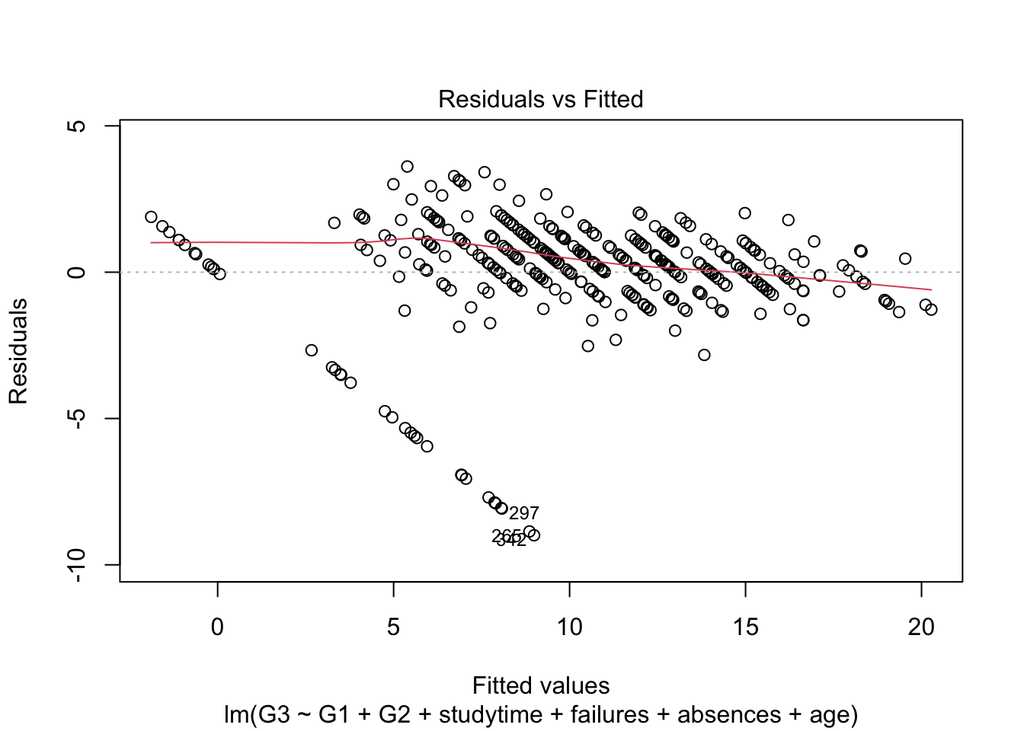

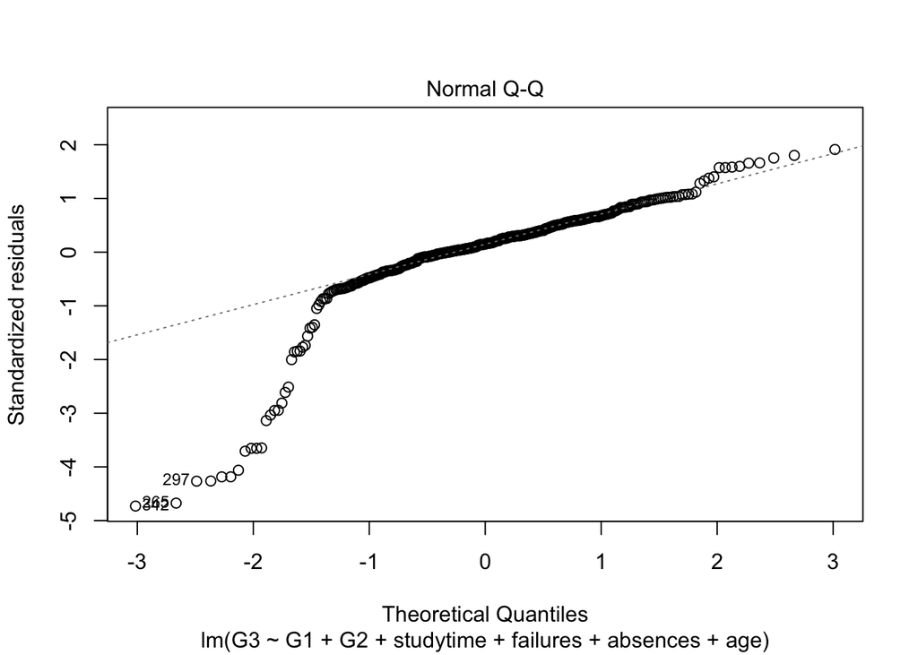

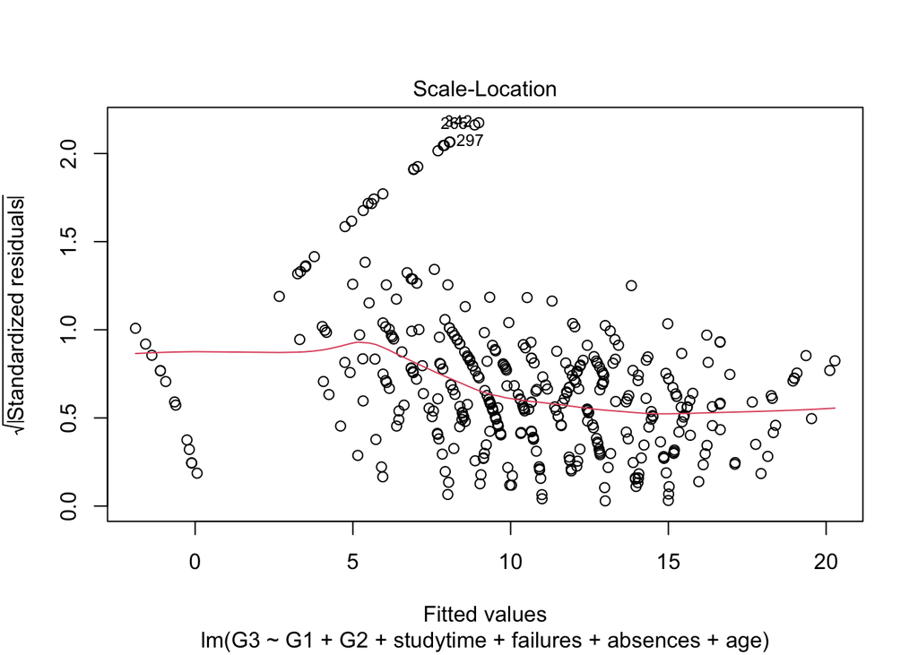

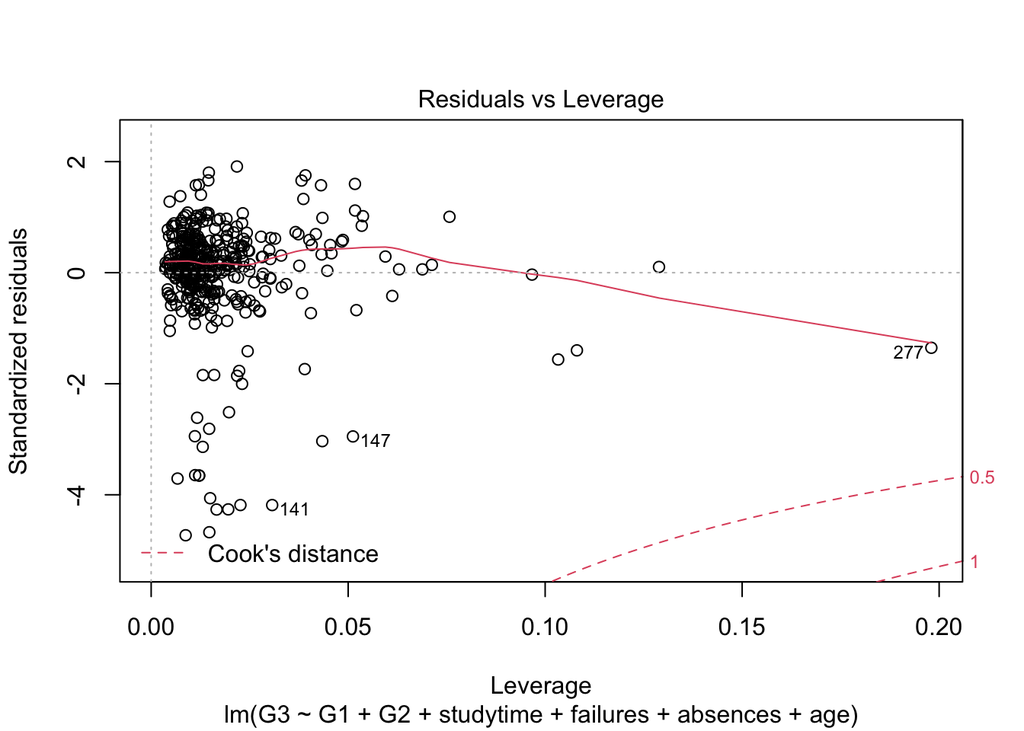

```r
plot(M2) #Vẽ các đồ thị kiểm tra các giả định
```

**Nhận xét**:

**Đồ thị 1:** Như trên.

**Đồ thị 3:** vẽ căn bậc hai của các giá trị thặng dư được chuẩn hoá bởi các giá trị dự báo, được dung để kiểm tra giả định thứ 3 (phương sai của các sai số là hằng số - tương tự đồ thị 1). Nếu đường màu đỏ trên đồ thị là đường thẳng nằm ngang và các giá trị thặng dư phân tán đều quanh đường thẳng này thì giả định 3 được thoả. Nếu như đường màu đỏ có độ dốc (hoặc cong) hoặc các điểm thẳng dư phân tán không đều xung quanh đường thẳng này, thì giả định thứ 3 bị vi phạm.

Dựa trên đồ thị ta thấy đường màu đỏ trên đồ thị là đường thẳng hơi nghiêng và các giá trị thặng dư phân tán đều quanh đường thẳng. Mặc dù đồ thị cho ta thấy rằng giả định tính đồng nhất về phương sai cũng hơi bị vi phạm. Tuy nhiên, ta cũng thấy vi phạm này tương đối nhỏ và có thể chấp nhận được.

**Đồ thị 4:** Cho phép xác định được những ảnh hưởng cao, nếu chúng có hiện diện trong dữ liệu. Những điểm ảnh hưởng cao này có thể là các điểm outliers, là những điểm gây nhiễu gây ảnh hưởng nhiều nhất trong việc phân tích. Nếu như ta thấy đường màu đỏ đứt nét (Cook’s distance) và có một số điểm vượt qua đường khoảng cách này, nghĩa là các điểm đó có ảnh hưởng cao. Nếu như không có điểm nào vượt qua nó, nghĩa là không có điểm nào thực sự có ảnh hưởng cao.

Dựa vào đồ thị, ta nhận thấy quan trắc thứ 141, 147, 277 có thể là những điểm có ảnh hưởng cao trong bộ dữ liệu. Tuy nhiên các điểm chưa vượt qua đường khoảng cách Cook, do vậy các điểm này chưa thực sự là các điểm có ảnh hưởng cao trong bộ dữ liệu. Do đó ta không cần phải loại bỏ chúng khi phân tích.

**5) DỰ BÁO**:

1. Dùng lệnh **prop.table** và **table** để thống kê tỷ lệ đạt/ không đạt của sinh viên trong điểm thi cuối kỳ dựa trên số liệu quan sát:

```r
evaluate = prop.table(table(new_DF$G3>=10))  #Thống kê tỷ lệ đạt/ không đạt của 'G3' (quan sát)
evaluate  #Xem kết quả
```

```
##
##    FALSE     TRUE
## 0.325641 0.674359
```

**Nhận xét:**

Tỷ lệ không đạt của sinh viên trong điểm thi cuối kì : 32,5641%

2. Lập một bảng số liệu mới đặt tên là **new_X** bao gồm toàn bộ các biến độc lập trong mô hình.

```r
new_X=data.frame(new_DF[,c(1,2,4,5,6,7,8)])  #Tạo bảng số liệu 'new_X'
head(new_X, 3)  #Xuất 3 dòng đầu tiên của data 'new_X'
```

```
##   G1 G2 studytime failures absences higher age
## 1  5  6         2        0        6    yes  18
## 3  7  8         2        3       10    yes  15
## 4 15 14         3        0        2    yes  15
```

Dùng lệnh **predict** để đưa ra số liệu dự báo cho biến phụ thuộc **G3** vào **new_X**, đặt tên biến này là **pred_G3**.

```r
new_X$pred_G3 = predict(M2,new_X)  #Dự báo biến 'G3'
head(new_X, 3)  #Xuất 3 dòng đầu tiên của data 'new_X'
```

```
##   G1 G2 studytime failures absences higher age   pred_G3
## 1  5  6         2        0        6    yes  18  4.744700
## 3  7  8         2        3       10    yes  15  7.027707
## 4 15 14         3        0        2    yes  15 14.292682
```

Dùng lệnh **prop.table** và **table** để thống kê tỷ lệ đạt/ không đạt của sinh viên trong điểm thi cuối kỳ dựa trên số liệu dự báo:

```r
evaluate1 = prop.table(table(new_X$pred_G3>=10)) #Thống kê tỷ lệ đạt/ không đạt của 'G3' (dự báo)
evaluate1  #Xem kết quả
```

```
##
##     FALSE      TRUE
## 0.4692308 0.5307692
```

**Nhận xét:**

Tỷ lệ đạt của sinh viên trong điểm thi cuối kì : 53,07692%

Tỷ lệ không đạt của sinh viên trong điểm thi cuối kì : 46,92308%

3. Lập bảng so sánh kết quả dự báo **pred_G3** với kết quả thực tế của biến **G3**.

```r
Ket_qua = data.frame(cbind(evaluate,evaluate1))  #Tạo bảng so sánh kết quả
colnames(Ket_qua)=c("Quan sát","Dự báo")  #Đổi tên cột
rownames(Ket_qua)=c("Không đạt", "Đạt")  #Đổi tên hàng
t(Ket_qua) #Xuất kết quả
```

```
##          Không đạt       Đạt
## Quan sát 0.3256410 0.6743590
## Dự báo   0.4692308 0.5307692
```

**Nhận xét:** Dựa trên kết quả, ta có thể nhận xét tỷ lệ đạt/không đạt ở quan sát và dự báo, có sự chệnh lệch đáng kể. Có thể giải thích là do mô hình hồi quy ta xây dựng chưa thực sự tốt, ví lý do có nhiều ngoại lại ảnh hưởng đến kết quả ta dự báo. Ta cần xử lí trước khi xây dựng mô hình để mô hình tốt hơn.